# RESUMO FFMS

### By Core Portfolios status (`port_core`)

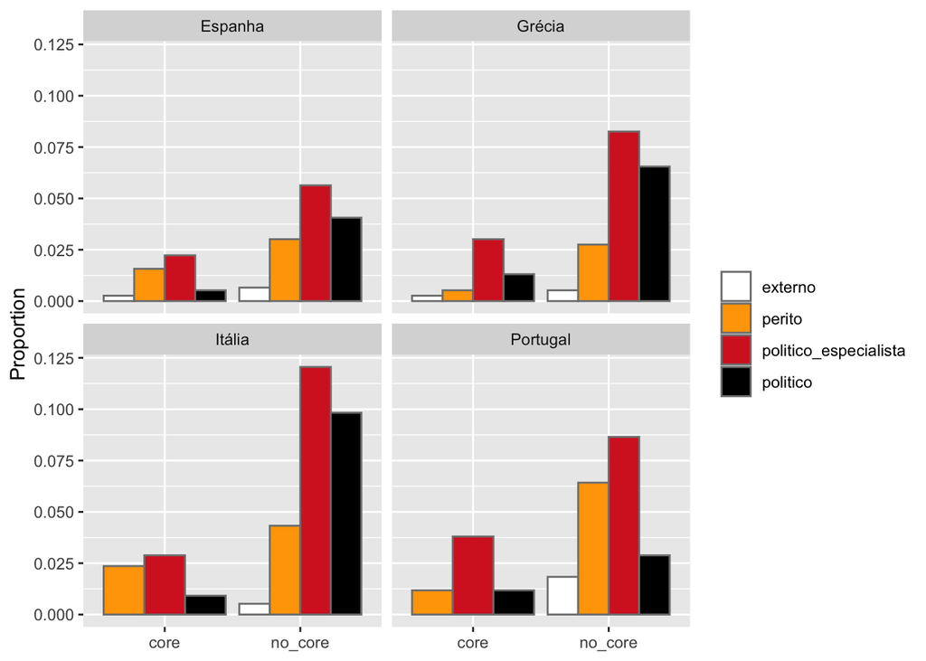

### By Portfolios’ Field (`port_field_AggA`)

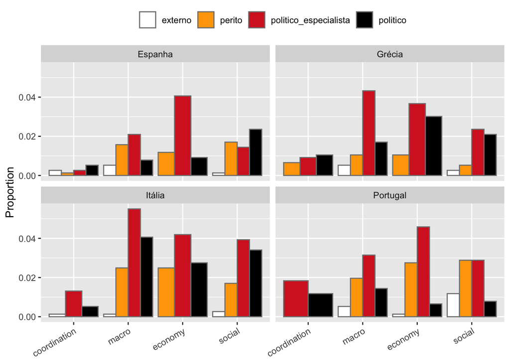

### Formal structure (port_type)

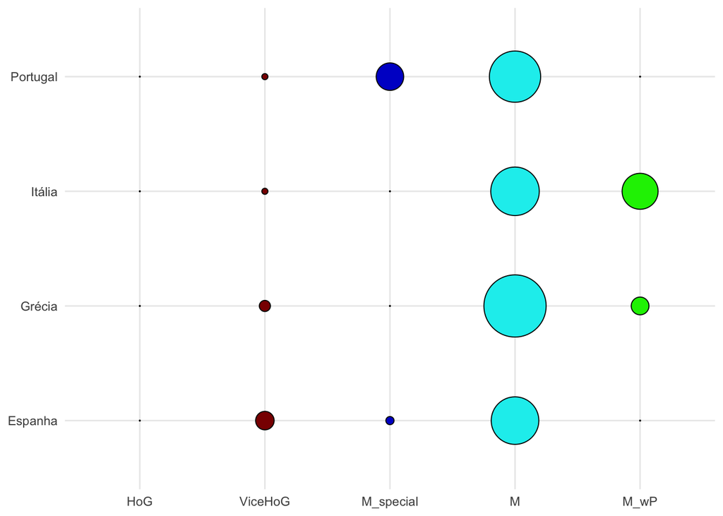

### Core portfolios (`port_core`)

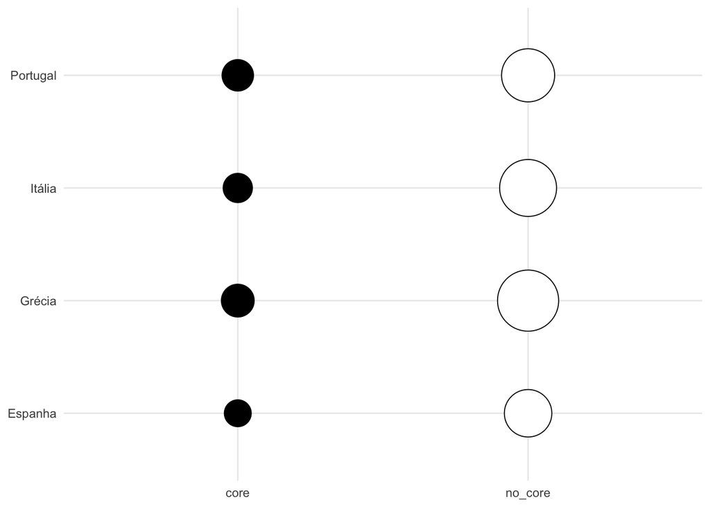

### Portfolio field (`port_field_AggA`)

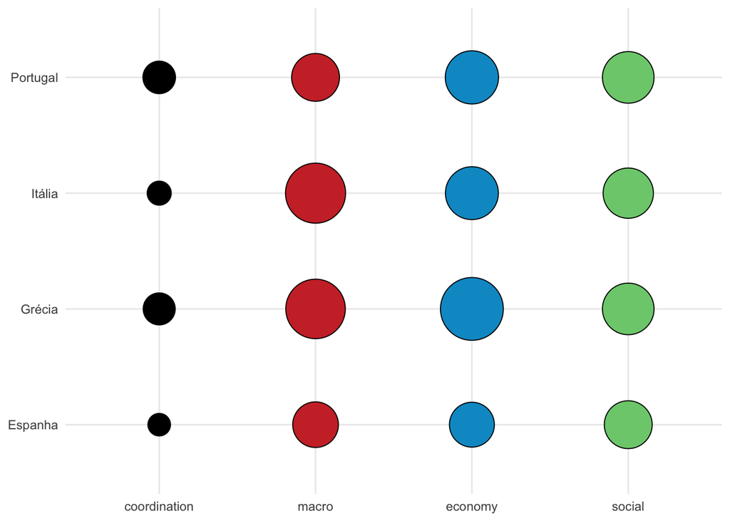

### TURNOVER

#### Duration

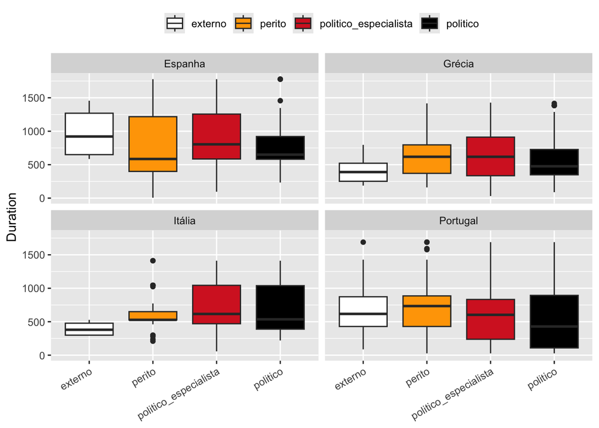

## R.LOGISTICA

### time

A variável gov_order representa a ordem cronológica dos governos, permitindo analisar se há alguma tendência temporal na distribuição dos perfis ministeriais.

Os resultados mostram que, ao longo do tempo, há um aumento estatisticamente significativo na probabilidade de nomeação de ministros classificados como perito e politico_especialista, em comparação com o perfil de referência (politico_generalista):

Para os perito, o odds ratio de 1.066 indica que, a cada novo governo, a chance relativa de nomeação desse perfil aumenta em cerca de 6,6%, e esse efeito é estatisticamente significativo (p = 0.002).

Para os politico_especialista, o odds ratio de 1.10 indica um aumento de cerca de 10,3% por governo, também altamente significativo (p < 0.001).

Já para os externo, não há variação estatisticamente significativa ao longo do tempo (p = 0.33).

Isso sugere que, com o passar do tempo, cresce a propensão a nomear ministros com perfis mistos de especialização política e técnica, sendo esse aumento mais pronunciado no caso dos politico_especialista (experiência política e técnica combinadas) do que no dos perito (com expertise externa, mas menos experiência política).

### coal

Nos governos de coligação, os perfis externo e perito têm significativamente menos probabilidade de serem nomeados, em comparação com o perfil politico_generalista.

Para externo, a razão de chances (odds ratio) é 0.29 (p = 0.0029), o que indica que as chances de nomeação desse perfil são aproximadamente 71% menores em governos de coligação do que em governos monopartidários.

Para perito, o odds ratio é 0.36 (p = 0.00088), correspondendo a uma redução de cerca de 64% nas chances de nomeação em governos de coligação.

Já o perfil politico_especialista não apresenta diferenças estatisticamente significativas em relação ao politico_generalista (odds ratio = 1.14, p = 0.61).

Os interceptos indicam que, mesmo em governos monopartidários (grupo de referência), os perfis externo e especialista são menos prováveis que o politico_generalista, embora essas diferenças não sejam estatisticamente significativas.

### leg

Nos governos minoritários, os perfis externo e especialista têm significativamente mais probabilidade de serem nomeados, em comparação com o perfil politico_generalista.

Para externo, a razão de chances (odds ratio) é 7.24 (p < 0.001), ou seja, as chances de nomeação são mais de sete vezes maiores do que em governos maioritários. A diferença é altamente significativa.

Para especialista, o odds ratio é 2.88 (p < 0.001), indicando que esse perfil também é mais provável em governos minoritários, com quase o triplo de chances. A diferença é estatisticamente significativa.

Já o perfil politico_especialista apresenta odds ratio de 1.25 (p = 0.41), sugerindo uma leve elevação nas chances, mas sem significância estatística.

Os interceptos indicam as probabilidades relativas de nomeação em governos maioritários, tomando politico_generalista como referência. Os perfis externo (OR = 0.16, p < 0.001) e especialista (OR = 0.67, p = 0.049) são menos prováveis que politico_generalista. Já o perfil politico_especialista é mais comum em governos maioritários (OR = 1.52, p = 0.010).

Estes resultados sugerem que em contextos de maioria parlamentar há preferência por perfis políticos típicos (especialmente politico_especialista e politico_generalista), enquanto em governos minoritários há maior propensão a nomear perfis mais “externos” ou independentes (externo, especialista).

### port-core

Análise do impacto da importância do ministério (port_core, com categoria de referência “não central”) na composição dos perfis ministeriais: Comparando ministérios centrais (core) com os não centrais (no_core), observa-se que os perfis externo e especialista têm significativamente menos probabilidade de serem nomeados nos ministérios centrais, em comparação com o perfil politico_generalista.

Para o perfil externo, a razão de chances (odds ratio) é 0.26 (p = 0.019), indicando que as chances de nomeação em ministérios centrais são cerca de 74% menores do que em ministérios não centrais, relativamente ao perfil politico_generalista.

Para o perfil especialista, o odds ratio é 0.49 (p = 0.052), mostrando uma tendência a menor probabilidade em ministérios centrais, marginalmente significativa.

Para o perfil politico_especialista, o odds ratio é 0.98 (p = 0.93), sugerindo que não há diferença significativa entre ministérios centrais e não centrais em relação ao perfil politico_generalista.

Os interceptos indicam que, mesmo em ministérios não centrais (categoria de referência), o perfil externo é menos provável que o politico_generalista (OR = 0.64, p = 0.02), enquanto politico_especialista é mais provável que politico_generalista (OR = 1.67, p = 0.0008). Para especialista, não há diferença estatisticamente significativa em relação ao politico_generalista nos ministérios não centrais.

### full